# 03: Example Exploratory Data Analysis

Ben Campbell

2024-07-14

# Introduction and Motivation

Jesse Johnson (UK) and Ashley Leeds (Rice) have a well known 2011 piece in Foreign Policy Analysis that examines the effect of alliances on conflict, esentially finding that the presence of an alliance within a dyad influences conflict in varying ways between 1816-2000:

- Deterrence: If a targeted state has a defensive alliance, they may be less likely to be attacked.
- Empowerment: If a challenging state has an offensive alliance, they may be more likely to initiate conflict.

But there’s been a lot of discussion about how the development of nuclear weapons may undermine the effect of alliances in deterring conflict. As such, we will briefly examine whether these effects hold on a subset of the data occuring after World War 2.

*Disclaimer: This is an ongoing debate and this isn’t the most rigorous way to address this question. I’m also like 5+ years removed from this literature so who knows where it’s at now.*

# Data Preparation

## Importing Data

We will start with importing the data. Leeds and Johnson conducted their analysis in Stata (hiss!), so we will have to rely upon packagesto import this data. Here, we will use Thomas Leeper’s `rio` package, although Hadley Wickham’s `haven` package may also be useful. `rio` is nice because it only uses one function and takes care of a lot of clean up.

Here, since I only want one function from `rio`, the import function, I’m not going to attach the whole package but instead point R to the `import` function in `rio` using the `::` operator. This is good practice as it promotes clarity in where you are drawing certain functions. If you, however, are using a lot of functions from the same package, you may use `library()`.

This will take a few seconds as it is 1,000,000+ directed dyads.

```r
install.packages(c("rio", "Rmisc", "texreg"), repos='http://cran.us.r-project.org')
dat <- rio::import('~/code/math-workshop-instructor/R/data/LeedsJohnsonJOPrep.dta')
```

## Spot Checking

When you’re reading in data, it’s always a good idea to spend some time spot checking to make sure things loaded in appropriately.

```r
head(dat)
```

```
##   challenger target ddyad year dispute ptargdef kvp_longitudinal_treatment
## 1          2     20  2020 1920       0        0                         NA
## 2          2     20  2020 1921       0        0                         NA
## 3          2     20  2020 1922       0        0                         NA
## 4          2     20  2020 1923       0        0                         NA
## 5          2     20  2020 1924       0        0                         NA
## 6          2     20  2020 1925       0        0                          0
##   pchalally pchaloff pchalneu   capprop ln_distance s_un_glo jdem peaceyrs
## 1         0        0        0 0.9662055    6.120297 0.931035    1        0
## 2         0        0        0 0.9600335    6.120297 0.898305    1        1
## 3         0        0        0 0.9681519    6.120297 0.900000    1        2
## 4         0        0        0 0.9650244    6.120297 0.900000    1        3
## 5         0        0        0 0.9661125    6.120297 0.901639    1        4
## 6         0        0        0 0.9668735    6.120297 0.901639    1        5
##   peaceyrs2 peaceyrs3 ptargoff ptargneu contig c_majpow t_majpow rivalyears
```

[output cut: 55 more lines]

```r
tail(dat)
```

```
##         challenger target  ddyad year dispute ptargdef
## 1077987        950    940 950940 1995       0        0
## 1077988        950    940 950940 1996       0        0
## 1077989        950    940 950940 1997       0        0
## 1077990        950    940 950940 1998       0        0
## 1077991        950    940 950940 1999       0        0
## 1077992        950    940 950940 2000       0        0
##         kvp_longitudinal_treatment pchalally pchaloff pchalneu   capprop
## 1077987                         NA         0        0        0 0.8737864
## 1077988                         NA         0        0        0 0.8737864
## 1077989                         NA         0        0        0 0.8737864
## 1077990                         NA         0        0        0 0.8712871
## 1077991                         NA         0        0        0 0.8712871
## 1077992                         NA         0        0        0 0.8712871
##         ln_distance s_un_glo jdem peaceyrs peaceyrs2 peaceyrs3 ptargoff
```

[output cut: 62 more lines]

One reasonable question is whether we are working with dyads or directed dyads. We cna do this by looking at COW codes:

```r
table(dat$challenger < dat$target)
```

```
##
##  FALSE   TRUE
## 538996 538996
```

## Filtering and Processing

Now we can subset the data down to only those dyad-years after 1945. This is done by essentially declaring some logical.

```r
range(dat$year)
```

```
## [1] 1816 2000
```

```r
table(dat$year)
```

```
##
##  1816  1817  1818  1819  1820  1821  1822  1823  1824  1825  1826  1827  1828
##   306   306   306   342   380   380   380   380   380   380   420   420   462
##  1829  1830  1831  1832  1833  1834  1835  1836  1837  1838  1839  1840  1841
##   462   506   552   600   600   600   600   600   600   600   702   702   812
##  1842  1843  1844  1845  1846  1847  1848  1849  1850  1851  1852  1853  1854
##   870   870   870   870   870   930  1056  1122  1122  1190  1190  1190  1260
##  1855  1856  1857  1858  1859  1860  1861  1862  1863  1864  1865  1866  1867
##  1332  1332  1332  1332  1406  1482  1122  1190  1122  1190  1190  1190  1190
##  1868  1869  1870  1871  1872  1873  1874  1875  1876  1877  1878  1879  1880
##  1190  1190  1190  1122   930   930   930   992  1056  1056  1190  1190  1190
##  1881  1882  1883  1884  1885  1886  1887  1888  1889  1890  1891  1892  1893
##  1122  1190  1260  1260  1260  1260  1406  1406  1406  1406  1406  1406  1406
##  1894  1895  1896  1897  1898  1899  1900  1901  1902  1903  1904  1905  1906
##  1482  1482  1482  1482  1560  1640  1722  1722  1806  1806  1806  1892  1806
```

[output cut: 16 more lines]

```r
table(is.na(dat$year))
```

```
##
##   FALSE
## 1077992
```

```r
postWW2 <- dat[dat$year > 1945,]
```

Note, R doesn’t know what to do with NA’s, so if we had missingness in a variable we were trying to subset on, we might have some issues:

```r
NA > 1945
```

```
## [1] NA
```

Let’s double check we did this right

```r
range(dat$year)
```

```
## [1] 1816 2000
```

```r
range(postWW2$year)
```

```
## [1] 1946 2000
```

Let’s remove the `dat` object to free up space. Note, we need to first remove it from our workspace, and then call the garbage collector to free up memory.

```r
rm(dat)
gc()
```

```
##            used  (Mb) gc trigger   (Mb) limit (Mb)  max used  (Mb)
## Ncells   755155  40.4    1439647   76.9         NA   1439647  76.9
## Vcells 52146567 397.9  137030759 1045.5      32768 124603125 950.7
```

# Visual Exploratory Data Analysis

## Univariate Analysis

So, we have the data we are interested in examining all laid out. Let’s start by doing some univariate visualizations of the data. *Note: Usually, before you get here, you’d have to clean your data first. Cleaning and collecting your data is like 90% of industry data science work* These data are fairly clean though.

While most of our primary variables are dichotomous, a few are continuously measured and should be visualized using certain tools,such as histograms or density plots.

The following variables are continuous:

- `capprop`: Challenger’s probability of winning
- `ln_distance`: log distance in KM between challenger and target
- `s_un_glo`: similarity in alliance portolios

Since we want to do the same plots for the same variables, because of this, might be easier to make a function. First, let’s make a function to make histograms using `ggplot2`

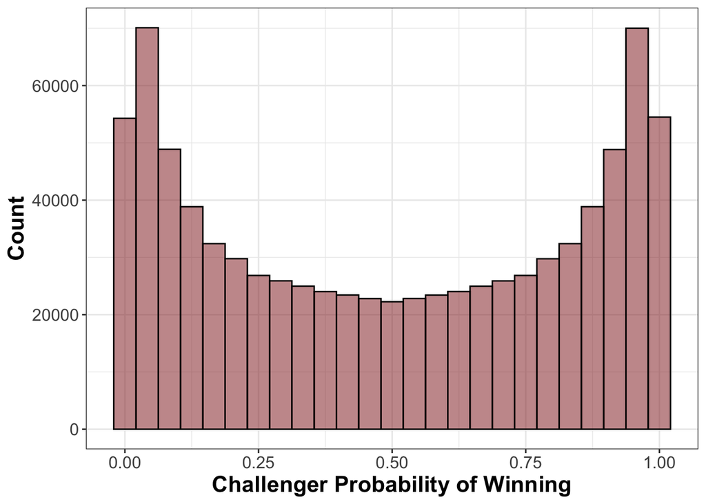

```r
# load ggplot2
library(ggplot2)
# create function with 4 arguments, the variable as a vector,
# the character string for the x axis
# the character string for the title
# the number of bins

make_histogram <- function(var = NULL,
                           xaxis = NULL,
                           title = NULL,
                           nbins = 30){
  p <- ggplot(data = postWW2, aes(var)) + # initialize plot
    geom_histogram(bins = nbins, alpha = 0.5, color = "black",
                   fill = "firebrick4") + # add histogram layer using nbins,
                                          # add some transparency using alpha,
                                          # add some color
    xlab(xaxis) + # plug in xaxis argument
    ylab("Count") + # define y axis label
    ggtitle(title) + # plug in title
    theme_bw() +  # make the background white
    theme(plot.title = element_text(size=16, face='bold'), # change title font
      axis.title = element_text(size=16, face='bold'), # change axis title font
      axis.text=element_text(size=12)) # change axis text font
  # return p
  return(p)
}

# histogram for capprop
capprop_hist <- make_histogram(var = postWW2$capprop,
                               xaxis = "Challenger Probability of Winning",
                               nbins = 25)
# print it
capprop_hist
```

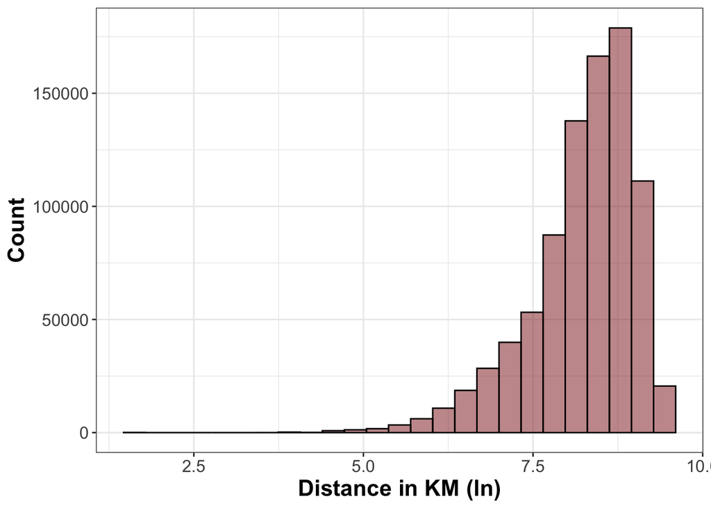

```r
# histogram for ln_distance
ln_distance_hist <- make_histogram(var = postWW2$ln_distance,
                               xaxis = "Distance in KM (ln)",
                               nbins = 25)
# print it
ln_distance_hist
```

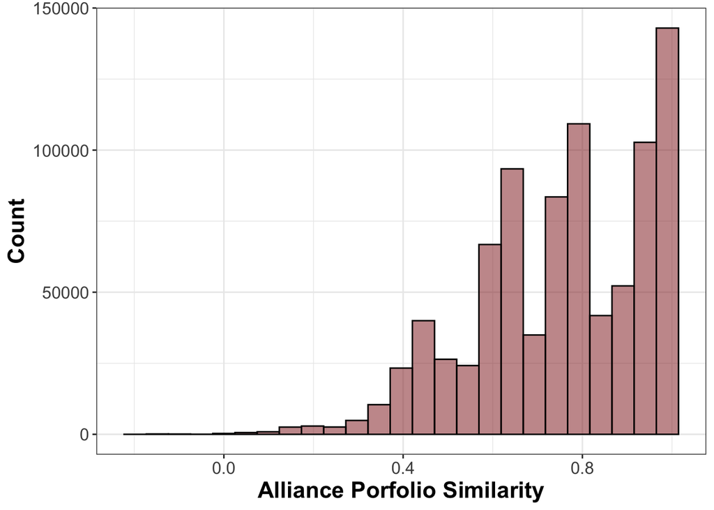

```r
# histogram for s_un_glo
s_un_glo_hist <- make_histogram(var = postWW2$s_un_glo,
                                   xaxis = "Alliance Porfolio Similarity",
                                   nbins = 25)
# print it
s_un_glo_hist
```

Hmmm, what if we wanted to arrange these plots together?

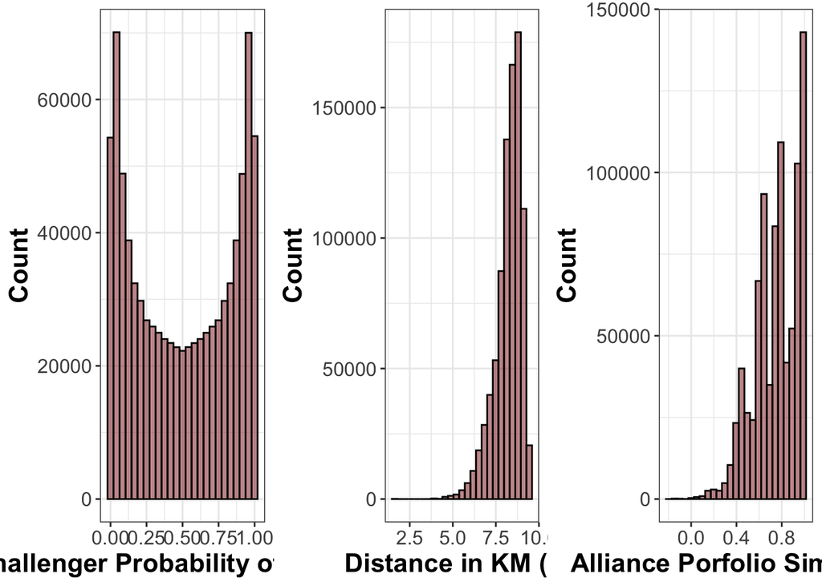

```r
# What if you want these plots next to one another?
# put them in a list
hist_list <- list(capprop_hist, ln_distance_hist, s_un_glo_hist)

# use the multiplot function in Rmisc to put them in a common layout
Rmisc::multiplot(plotlist = hist_list, cols = 3)
```

What if we wanted to save these in a file?

```r
# Or we can save them to a file
pdf("HistPlots.pdf")
Rmisc::multiplot(plotlist = hist_list, cols = 3)
dev.off()

# shucks! a little smooshed, stretch the plot width wise
pdf("HistPlots.pdf", width = 14)
Rmisc::multiplot(plotlist = hist_list, cols = 3)
dev.off()
```

We could also make density plots, thankfully ggplot makes this super easy.

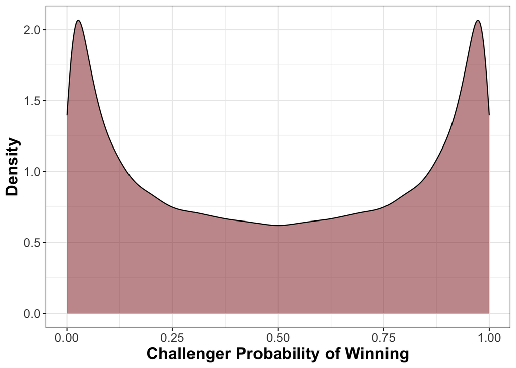

```r
# You could also plot these as density plots, which may be better for
# visualization as it avoids binning bias:
make_density <- function(var = NULL,
                         xaxis = NULL,
                         title = NULL){
  p <- ggplot(data = postWW2, aes(var)) + # initialize plot
    # add density layer, add some transparency using alpha, add some color
    geom_density(alpha = 0.5, color = "black", fill = "firebrick4") +
    xlab(xaxis) + # plug in xaxis argument
    ylab("Density") + # define y axis label
    ggtitle(title) + # plug in title
    theme_bw() +  # make the background white
    theme(plot.title = element_text(size=16, face='bold'), # change title font
        axis.title = element_text(size=16, face='bold'),# change axis title font
        axis.text=element_text(size=12)) # change axis text
  # return p
  return(p)
}

# density for capprop
capprop_dens <- make_density(var = postWW2$capprop,
                               xaxis = "Challenger Probability of Winning")
# print it
capprop_dens
```

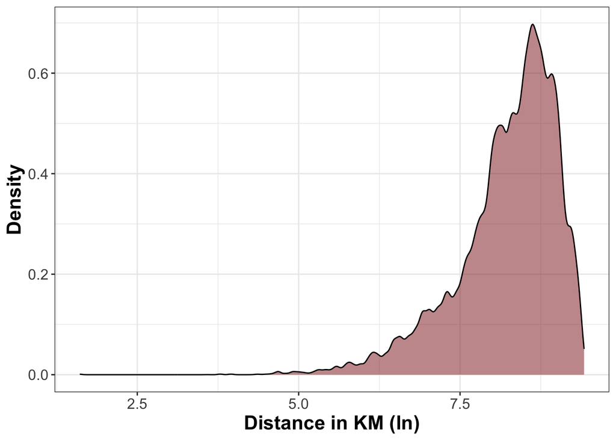

```r
# density for ln_distance
ln_distance_dens <- make_density(var = postWW2$ln_distance,
                                   xaxis = "Distance in KM (ln)")
# print it
ln_distance_dens
```

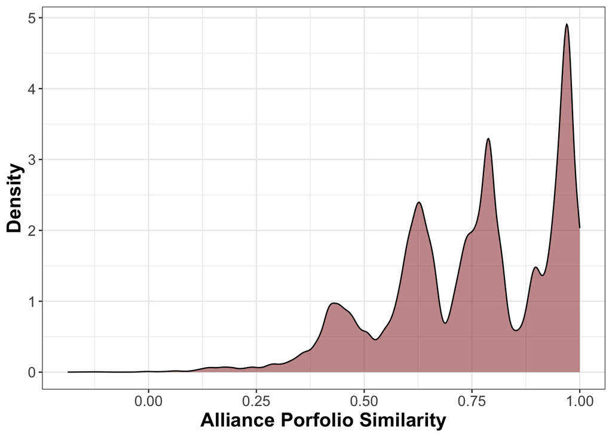

```r
# density for s_un_glo
s_un_glo_dens <- make_density(var = postWW2$s_un_glo,
                                xaxis = "Alliance Porfolio Similarity")
# print it
s_un_glo_dens
```

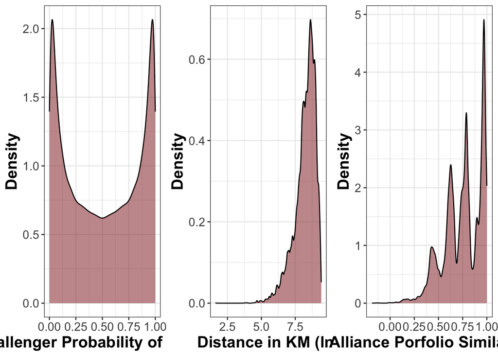

```r
# What if you want these plots next to one another?
# put them in a list
density_list <- list(capprop_dens, ln_distance_dens, s_un_glo_dens)

# use the multiplot function in Rmisc to put them in a common layout
Rmisc::multiplot(plotlist = density_list, cols = 3)
```

We still have a decent number of dichotomous variables though, how do we handle those? We should use bar graphs!

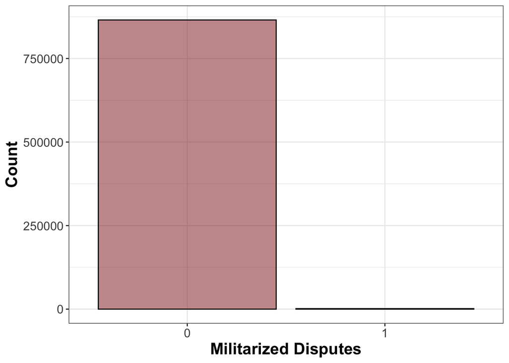

```r
# make bar graph function
make_bargraph <- function(var = NULL,
                         xaxis = NULL,
                         title = NULL){
  p <- ggplot(data = postWW2, aes(var)) + # initialize plot
    # add bar layer, add some transparency using alpha, add some color
    geom_bar(alpha = 0.5, color = "black", fill = "firebrick4") +
    xlab(xaxis) + # plug in xaxis argument
    ylab("Count") + # define y axis label
    ggtitle(title) + # plug in title
    theme_bw() +  # make the background white
    xlim("0", "1") +
    theme(plot.title = element_text(size=16, face='bold'), # change title font
        axis.title = element_text(size=16, face='bold'),# change axis title font
        axis.text=element_text(size=12)) # change axis text font
  # return p
  return(p)
}

# bar for dispute
dispute_bar <- make_bargraph(var = as.factor(postWW2$dispute),# factors help
                                                             # with x axis ticks
                             xaxis = "Militarized Disputes")
# print it
dispute_bar
```

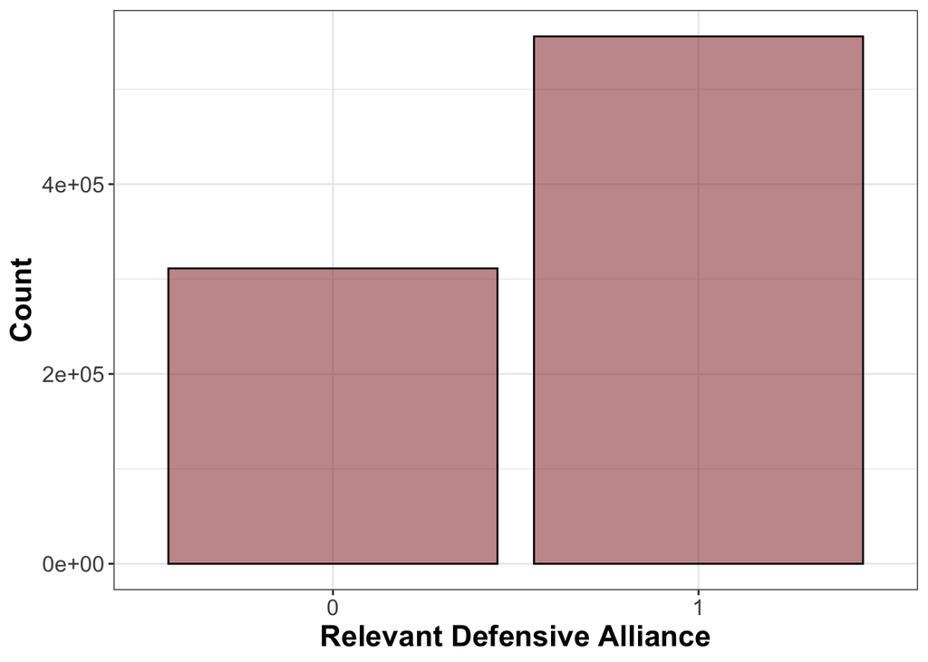

```r
# bar for ptargdef
ptargdef_bar <- make_bargraph(var = as.factor(postWW2$ptargdef),
                             xaxis = "Relevant Defensive Alliance")
# print it
ptargdef_bar
```

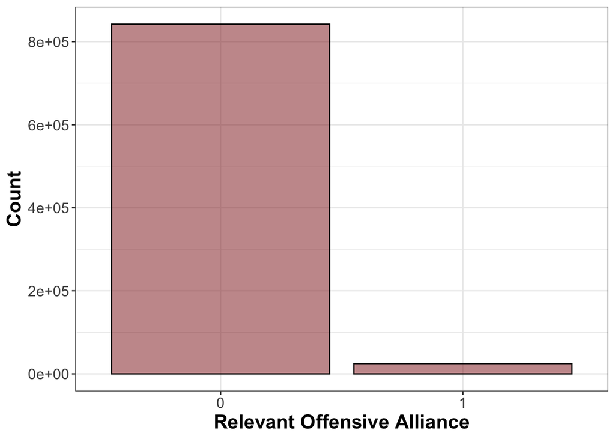

```r
# bar for pchaloff
pchaloff_bar <- make_bargraph(var = as.factor(postWW2$pchaloff),
                              xaxis = "Relevant Offensive Alliance")
# print it
pchaloff_bar
```

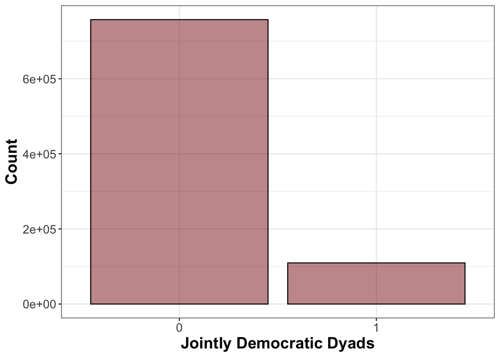

```r
# bar for jdem
jdem_bar <- make_bargraph(var = as.factor(postWW2$jdem),
                              xaxis = "Jointly Democratic Dyads")
# print it
jdem_bar
```

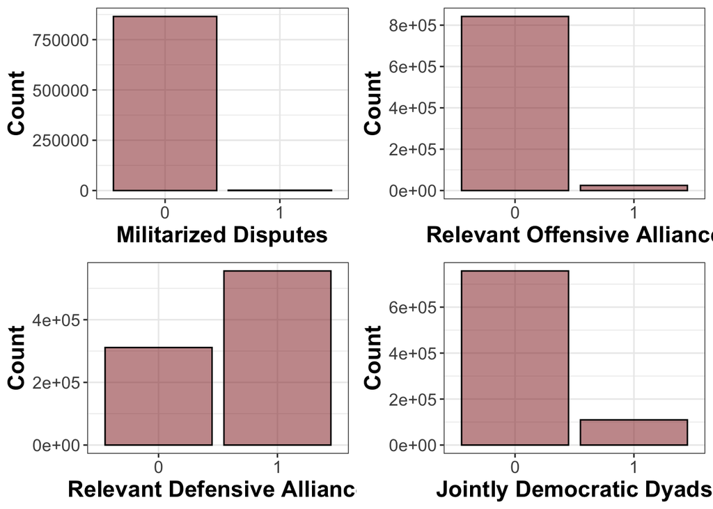

```r
# What if you want these plots next to one another?
# put them in a list
bar_list <- list(dispute_bar, ptargdef_bar, pchaloff_bar, jdem_bar)

# use the multiplot function in Rmisc to put them in a common layout
Rmisc::multiplot(plotlist = bar_list, cols = 2)
```

How about if we wanted to make sense of these as a function of time? These time series plots would be immensely helpful in chracterizing any systematic trends in the prevalence of certain phenomena.

```r
# get the years
years <- sort(unique(postWW2$year))

# initialize an empty data frame
plot_df <- data.frame()

# do a for loop! define a variable t which is iteratively drawn from years,
# takes a few seconds
for(t in years){
  # subset broader data frame down to a particular year
  year_df <- postWW2[postWW2$year == t,]
  # get the sum of each discrete variable for this annual data frame
  n_disputes <- sum(year_df$dispute, na.rm = TRUE)
  n_dem <- sum(year_df$jdem, na.rm = TRUE)
  n_def <- sum(year_df$ptargdef, na.rm = TRUE)
  n_off <- sum(year_df$pchaloff, na.rm = TRUE)

  # now, let's concatenate these all into a vector so that its a row
  row <- c(t, n_disputes, n_dem, n_def, n_off)

  # bind this row to the data frame
  plot_df <- rbind(plot_df, row)

}
  # as you become more experienced, you can move to using apply functions.
# apply functions are quicker than for loops.

# let's look at this
head(plot_df)
```

```
##   X1946 X6 X342 X2194 X192
## 1  1946  6  342  2194  192
## 2  1947  3  306  2296  259
## 3  1948 13  420  2780  480
## 4  1949 18  380  3258  501
## 5  1950 14  420  3591  437
## 6  1951 15  420  3862  443
```

```r
# ugly column names!
colnames(plot_df) <- c("year", "n_disputes", "n_dem", "n_def", "n_off")
head(plot_df)
```

```
##   year n_disputes n_dem n_def n_off
## 1 1946          6   342  2194   192
## 2 1947          3   306  2296   259
## 3 1948         13   420  2780   480
## 4 1949         18   380  3258   501
## 5 1950         14   420  3591   437
## 6 1951         15   420  3862   443
```

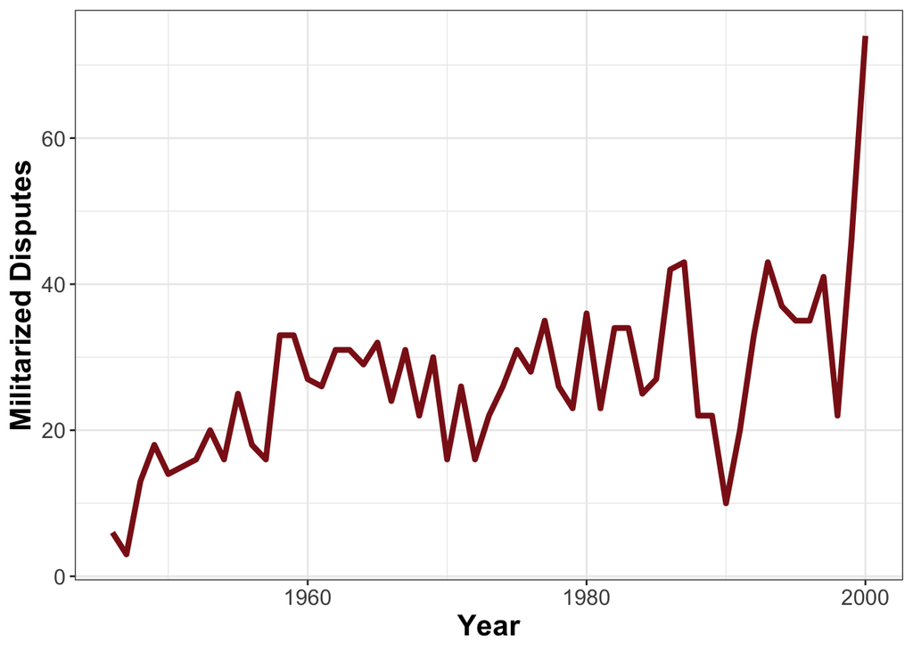

```r
# much better!

# let's plot each of these separately (given the differences in scales)
make_tsplot <- function(var = NULL,
                        yaxis = NULL,
                        title = NULL){
  p <- ggplot(data = plot_df, aes(x = year, y = var)) + # initialize plot
    geom_line(lwd = 1.5, color = "firebrick4") + # add thickish red line
    xlab("Year") + # plug in xaxis argument
    ylab(yaxis) + # define y axis label
    ggtitle(title) + # plug in title
    theme_bw() +  # make the background white
    theme(plot.title = element_text(size=16, face='bold'), # change title font
        axis.title = element_text(size=16, face='bold'),# change axis title font
        axis.text=element_text(size=12)) # change axis text font
  # return p
  return(p)
}

# line for dispute
# (factors help with x axis ticks)
dispute_tsp <- make_tsplot(var = plot_df$n_disputes,
                             yaxis = "Militarized Disputes")
# print it
dispute_tsp
```

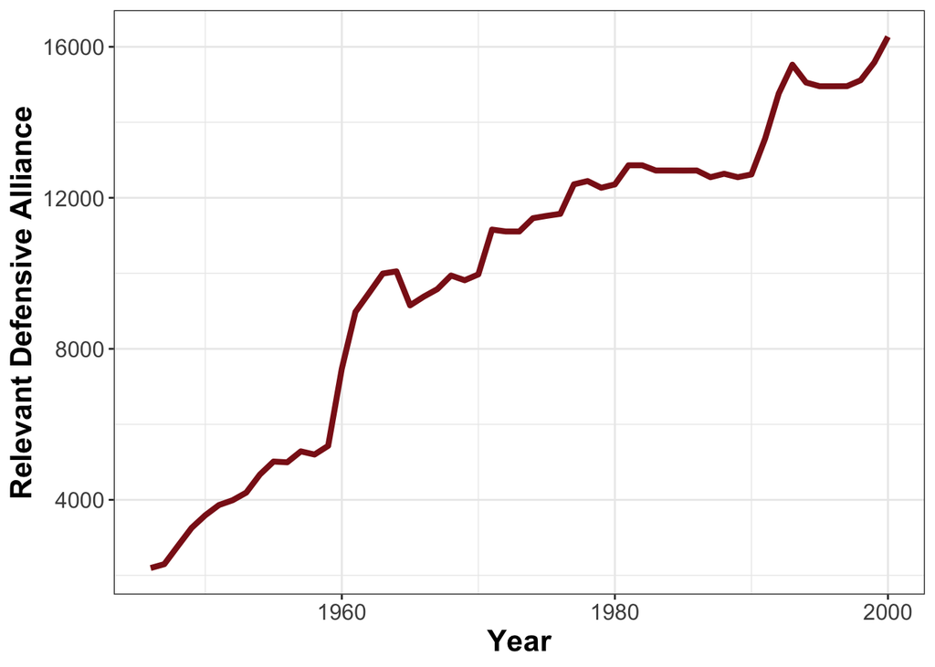

```r
# line for ptargdef
ptargdef_tsp <- make_tsplot(var = plot_df$n_def,
                            yaxis = "Relevant Defensive Alliance")
# print it
ptargdef_tsp
```

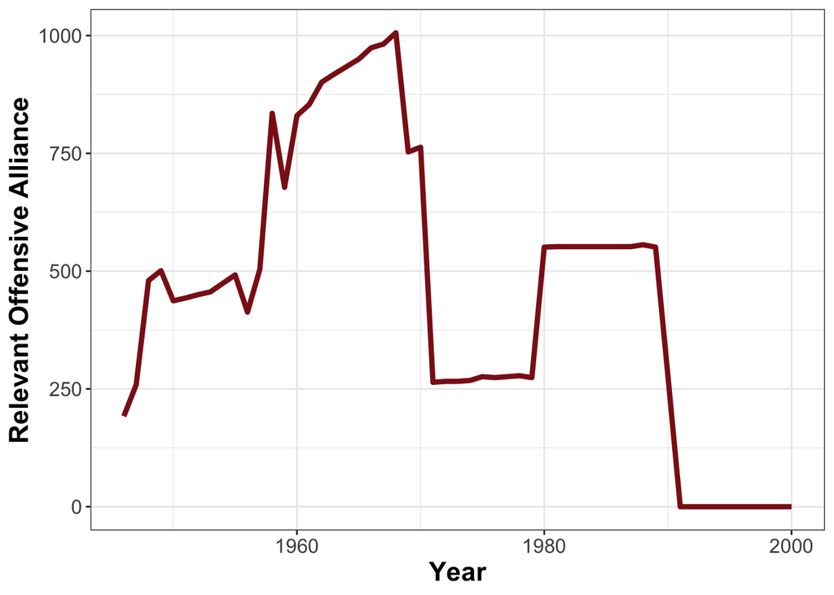

```r
# line for pchaloff
pchaloff_tsp <- make_tsplot(var = plot_df$n_off,
                            yaxis = "Relevant Offensive Alliance")
# print it
pchaloff_tsp
```

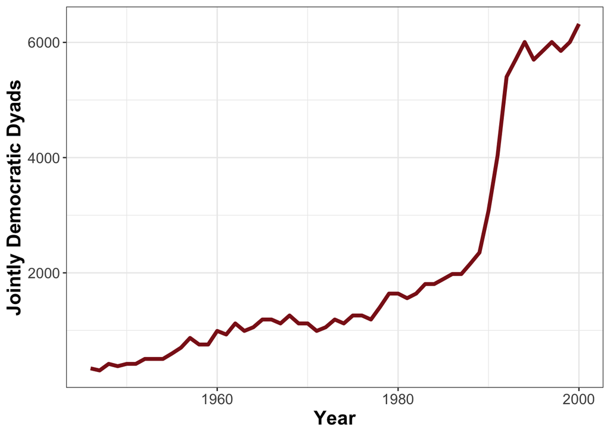

```r
# line for jdem
jdem_tsp <- make_tsplot(var = plot_df$n_dem,
                        yaxis = "Jointly Democratic Dyads")
# print it
jdem_tsp
```

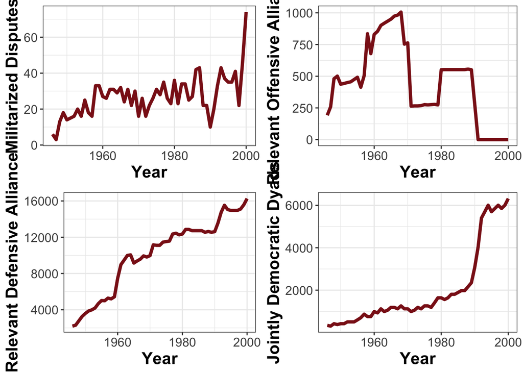

```r
# What if you want these plots next to one another?
# put them in a list
tsp_list <- list(dispute_tsp, ptargdef_tsp, pchaloff_tsp, jdem_tsp)

# use the multiplot function in Rmisc to put them in a common layout
Rmisc::multiplot(plotlist = tsp_list, cols = 2)
```

## Bivariate Analysis

Once we have visualized single variables, we’d often want to move to visualizing the relationships between variables using scatter plots. Let’s give this a shot for the two variables of interest!

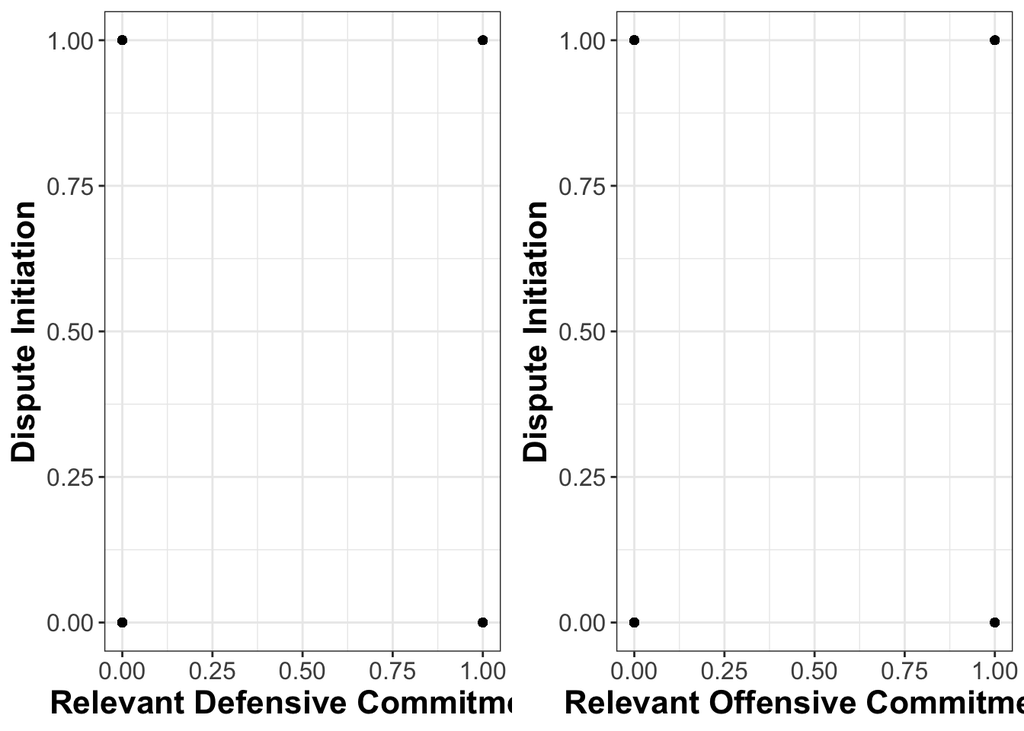

```r
p1 <- ggplot(data = postWW2, aes(x = ptargdef, y = dispute)) + # initialize plot
    geom_point() + # add thickish red line
    xlab("Relevant Defensive Commitment") + # plug in xaxis argument
    ylab("Dispute Initiation") + # define y axis label
    theme_bw() +  # make the background white
    theme(plot.title = element_text(size=16, face='bold'), # change title font
        axis.title = element_text(size=16, face='bold'),# change axis title font
        axis.text=element_text(size=12)) # change axis text font

p2 <- ggplot(data = postWW2, aes(x = pchaloff, y = dispute)) + # initialize plot
  geom_point() + # add thickish red line
  xlab("Relevant Offensive Commitment") + # plug in xaxis argument
  ylab("Dispute Initiation") + # define y axis label
  theme_bw() +  # make the background white
  theme(plot.title = element_text(size=16, face='bold'), # change title font
        axis.title = element_text(size=16, face='bold'),# change axis title font
        axis.text=element_text(size=12)) # change axis text font

# any guesses to what these look like?
scatter_list <- list(p1, p2)

Rmisc::multiplot(plotlist = scatter_list, cols =2)
```

# Quantitative Exploratory Data Analysis

Quantitive EDA is a means of providing summary statistics for variables or the relationship between variables. At the very basic level, we can calculate the following:

- Frequencies of variables
- Central tendencies (mean, median)
- Measures of spread (std. deviation, variance, range)
- Percentiles of variables
- Pearson correlations between variables
- T-tests for differences in means

## Univariate Analysis

We will start with the univariate case and then move to bivariate quantitative EDA.

```r
# let's define a list of variables that we are interested in summarizing,
# those we've previously used
vars <- list("dispute", "ptargdef", "pchaloff", "capprop", "ln_distance",
             "s_un_glo", "jdem")

# as I mentioned, apply family functions are faster than for loops
# and take at min. 2 arguments, data and a function to repetitively
# perform on that data.
# here, the data is the list vars
# the function is a univariate eda function we will write
# to do everything for us

univariate_eda <- function(var){
  # define var as a vector
  varname <- var
  var <- postWW2[,var]
  # get summary statistics
  table_out <- summary(var)

  # if dichotomous, get the frequencies
  # (which would be odd for continuous variables)
  if(length(unique(var)) == 2){
    frequencies_out <- table(var)
  } else {
    # we need to return a variable frequencies out, so, if not calculating them,
    # give it a null
    frequencies_out <- NULL
  }

  # calculate measures of spread
  sd_out <- sd(var, na.rm = TRUE)
  var_out <- sd_out^2
  range_out <- range(var)

  # put in a named list
  out_list <- list(variable = varname,
                   summary_stats = table_out,
                   frequencies = frequencies_out,
                   stddev = sd_out,
                   variance = var_out,
                   var_range = range_out)
  return(out_list)
}

# going to use lapply or list apply, which applies a function over a list
var_desc <- lapply(vars, univariate_eda)

# we can not index these according to the order that we feed the variables in
# Ex: for dispute
var_desc[[1]]
```

```
## $variable
## [1] "dispute"
##
## $summary_stats
##    Min. 1st Qu.  Median    Mean 3rd Qu.    Max.
## 0.00000 0.00000 0.00000 0.00171 0.00000 1.00000
##
## $frequencies
## var
##      0      1
## 865382   1482
##
## $stddev
## [1] 0.0413121
##
## $variance
## [1] 0.00170669
##
## $var_range
## [1] 0 1
```

We can also write out a text file with these results (good for batch execution of code).

```r
sink("VariableSummaries.txt")
var_desc
sink()
```

## Bivariate Analysis

Two-way frequency tables are commonly used, especially when the treatment and outcome are binary 1st arg is row, 2nd arg is column (standard in R):

```r
freq <- table(postWW2$ptargdef, postWW2$dispute)
rownames(freq) <- c("No Alliance", "Alliance")
colnames(freq) <- c("No Conflict", "Conflict")
freq
```

```
##
##               No Conflict Conflict
##   No Alliance      310690      541
##   Alliance         554692      941
```

Wow, conflict is rare, regardless of if there are alliances or not. In fact, it looks like there are more conflicts in dyads where a target has an alliance!

We can also calculate the cell proportions. This treats the denominator as the sum of all table values, each cell is the percentage of values. This indicates the fast number of dyads have no conflict but the target has an alliance:

```r
prop.table(freq)
```

```
##
##                No Conflict     Conflict
##   No Alliance 0.3584068551 0.0006240887
##   Alliance    0.6398835342 0.0010855221
```

This treats the denominator as the row sums. This indicates that conflict is relatively rare, regardless if the target has an alliance or not:

```r
prop.table(freq, 1)
```

```
##
##               No Conflict    Conflict
##   No Alliance 0.998261741 0.001738259
##   Alliance    0.998306436 0.001693564
```

This treats the denominator as the column sum. This indicates that in most cases of conflict, or no conflict, there are alliances.

```r
prop.table(freq, 2)
```

```
##
##               No Conflict  Conflict
##   No Alliance   0.3590206 0.3650472
##   Alliance      0.6409794 0.6349528
```

These may not be particularly useful though as conflict is a rare event. We can also do a variety of operations on this table, such as chi-squared tests:

```r
chisq.test(freq)
```

```
##
##  Pearson's Chi-squared test with Yates' continuity correction
##
## data:  freq
## X-squared = 0.20804, df = 1, p-value = 0.6483
```

Based upon this, we fail to reject the null that there is no relationship between alliances and conflict. In other words: it looks as if there may not be a relationship between these variables.

We can also use t-tests, which provide a means of assessing the difference in means for two samples of data, here the sample of dyads for which there is no relevant alliance and those for which there is a relevant alliance. We will call these the control and treatment samples:

```r
t_test_deterrence <- t.test(x = postWW2[postWW2$ptargdef == 0, "dispute"],
                            y = postWW2[postWW2$ptargdef == 1, "dispute"])
t_test_deterrence
```

```
##
##  Welch Two Sample t-test
##
## data:  postWW2[postWW2$ptargdef == 0, "dispute"] and postWW2[postWW2$ptargdef == 1, "dispute"]
## t = 0.48145, df = 637315, p-value = 0.6302
## alternative hypothesis: true difference in means is not equal to 0
## 95 percent confidence interval:
##  -0.0001372579  0.0002266475
## sample estimates:
##   mean of x   mean of y
## 0.001738259 0.001693564
```

We fail to reject the null, it looks like there may not be a difference between the two samples. We could also use Pearson correlations, which show a difference in the expected direction but not significant at any traditional level:

```r
corr_deterrence <- cor.test(x = postWW2$ptargdef, y = postWW2$dispute,
                            method = "pearson")
corr_deterrence
```

```
##
##  Pearson's product-moment correlation
##
## data:  postWW2$ptargdef and postWW2$dispute
## t = -0.48321, df = 866862, p-value = 0.6289
## alternative hypothesis: true correlation is not equal to 0
## 95 percent confidence interval:
##  -0.002624094  0.001586105
## sample estimates:
##           cor
## -0.0005189965
```

As we all know, however, there are a variety of variables that influence both the likelihood of alliances and the likelihood of a MID. In the language of causal inference, we refer to these as confounders! We need control variables here to help us isolate these effects. Enter logistic regression:

```r
logit <- glm(dispute ~ ptargdef + pchaloff + capprop + ln_distance + s_un_glo +
               jdem,
             data = postWW2,
             family = "binomial")

texreg::screenreg(logit)
```

```
##
## =============================
##                 Model 1
## -----------------------------
## (Intercept)          4.89 ***
##                     (0.26)
## ptargdef            -0.07
##                     (0.06)
## pchaloff            -0.08
##                     (0.12)
## capprop              0.57 ***
##                     (0.08)
## ln_distance         -1.30 ***
##                     (0.02)
## s_un_glo            -1.92 ***
##                     (0.17)
## jdem                -0.42 ***
##                     (0.08)
## -----------------------------
## AIC              18480.43
## BIC              18562.14
## Log Likelihood   -9233.21
## Deviance         18466.43
## Num. obs.       866864
## =============================
## *** p < 0.001; ** p < 0.01; * p < 0.05
```

```
## Model: bars denote standard errors (95%).
```

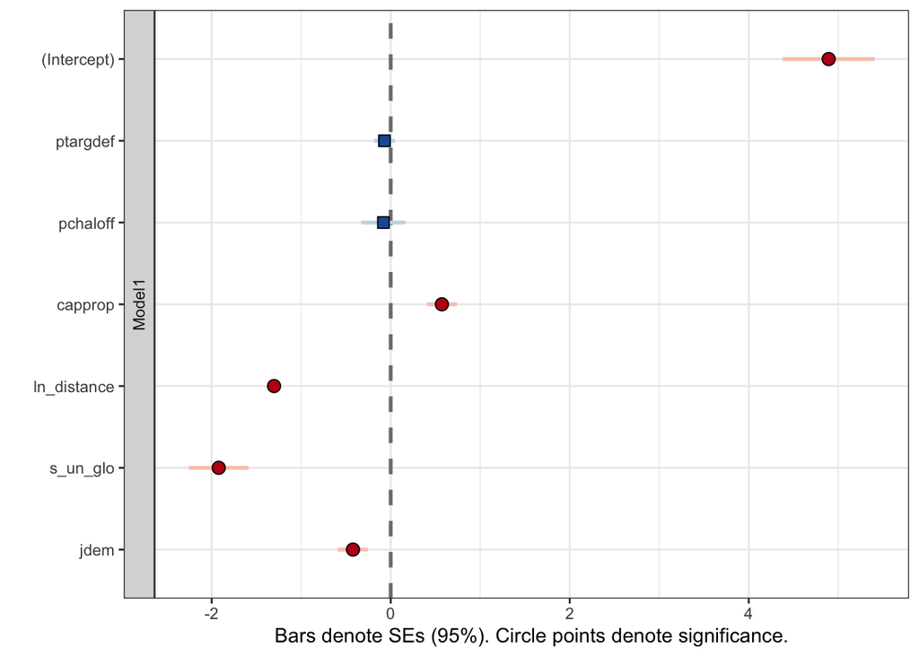

```r
texreg::plotreg(logit)
```